# NYPD Shooting Incident Data Analysis

CW

2023-02-20

## Library

```r
library("stringr")
library("tidyverse")
library("lubridate")
```

## Purpose

By analyzing number of murders during the time of day and number of murders from 2006 through 2021, it could target the time periods when police force should be out more than others to prevent murders, as well as potentially predicting the number of murders from historical data.

## Data Source

The data is downloaded from City of New York website, which includes a list of every shooting incident that occurred in New York from beginning of 2006 to the end of 2021.

```r
url_in <- "https://data.cityofnewyork.us/api/views/833y-fsy8/rows.csv?accessType=DOWNLOAD"
NYPD <- read_csv(url_in)
```

## Data Cleanup

By going through the data table, columns are removed, formats of date and time are converted, boolean flags are replaced with numeric indicators, N/A’s are removed, and date & time are combined into another variable. The table is then summarized.

```r
shooting <- select(NYPD, -c(INCIDENT_KEY, JURISDICTION_CODE, X_COORD_CD,
Y_COORD_CD, Latitude, Longitude, Lon_Lat)) %>%
  mutate(OCCUR_DATE=mdy(OCCUR_DATE)) %>%
  mutate(OCCUR_TIME=hms(OCCUR_TIME)) %>%
  mutate(STATISTICAL_MURDER_FLAG=ifelse(STATISTICAL_MURDER_FLAG==TRUE, 1, -1)) %>%
  unite(OCCUR_DATE_TIME, c(OCCUR_DATE, OCCUR_TIME), na.rm=TRUE, remove=FALSE)

summary(shooting)
```

```
##  OCCUR_DATE_TIME      OCCUR_DATE           OCCUR_TIME
##  Length:25596       Min.   :2006-01-01   Min.   :0S
##  Class :character   1st Qu.:2009-05-10   1st Qu.:3H 23M 0S
##  Mode  :character   Median :2012-08-26   Median :15H 10M 0S
##                     Mean   :2013-06-13   Mean   :12H 39M 17.9910923581774S
##                     3rd Qu.:2017-07-01   3rd Qu.:20H 45M 0S
##                     Max.   :2021-12-31   Max.   :23H 59M 0S
##      BORO              PRECINCT      LOCATION_DESC      STATISTICAL_MURDER_FLAG
##  Length:25596       Min.   :  1.00   Length:25596       Min.   :-1.0000
##  Class :character   1st Qu.: 44.00   Class :character   1st Qu.:-1.0000
##  Mode  :character   Median : 69.00   Mode  :character   Median :-1.0000
##                     Mean   : 65.87                      Mean   :-0.6149
##                     3rd Qu.: 81.00                      3rd Qu.:-1.0000
##                     Max.   :123.00                      Max.   : 1.0000
##  PERP_AGE_GROUP       PERP_SEX          PERP_RACE         VIC_AGE_GROUP
##  Length:25596       Length:25596       Length:25596       Length:25596
##  Class :character   Class :character   Class :character   Class :character
##  Mode  :character   Mode  :character   Mode  :character   Mode  :character
##
##
##
##    VIC_SEX            VIC_RACE
##  Length:25596       Length:25596
##  Class :character   Class :character
##  Mode  :character   Mode  :character
##
##
##
```

## Data Visualization

The data is further carved out to analyze the number of murders, both by time of the day and by year.

### Visualization 1

```r
murder_by_time <- shooting %>%
  filter(STATISTICAL_MURDER_FLAG==1) %>%
  group_by(OCCUR_TIME, STATISTICAL_MURDER_FLAG) %>%
  select(OCCUR_TIME, STATISTICAL_MURDER_FLAG, OCCUR_DATE) %>%
  summarize(num_murder_time=sum(STATISTICAL_MURDER_FLAG))
```

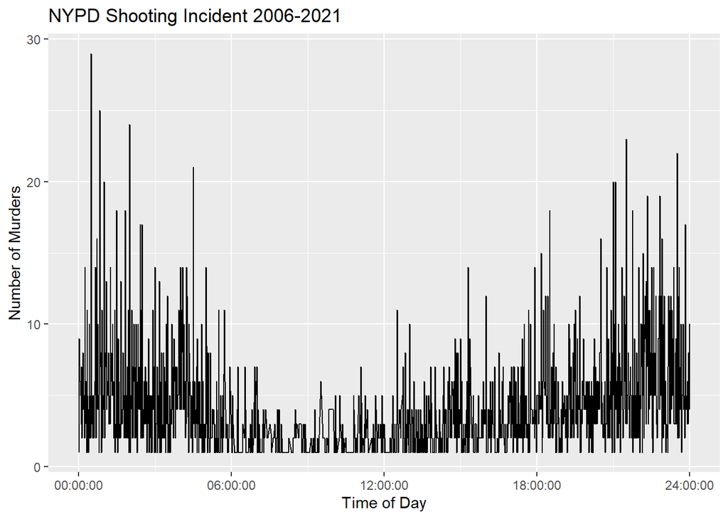

```r
murder_by_time %>%
  filter(STATISTICAL_MURDER_FLAG==1) %>%
  ggplot(mapping=aes(x=OCCUR_TIME, y=num_murder_time))+
  geom_line()+
  scale_x_time(breaks=c(0, 21600, 43200, 64800, 86400))+
  labs(title="NYPD Shooting Incident 2006-2021", x="Time of Day", y="Number of Murders")
```

As seen in the first plot, murders are usually concentrated at night times and in the early mornings, compared to middle of the day.

### Visualization 2

```r
murder_by_year <- shooting %>%
  filter(STATISTICAL_MURDER_FLAG==1) %>%
  group_by(OCCUR_YEAR=year(OCCUR_DATE), STATISTICAL_MURDER_FLAG) %>%
  select(OCCUR_YEAR, STATISTICAL_MURDER_FLAG) %>%
  summarize(num_murder_year=sum(STATISTICAL_MURDER_FLAG))
```

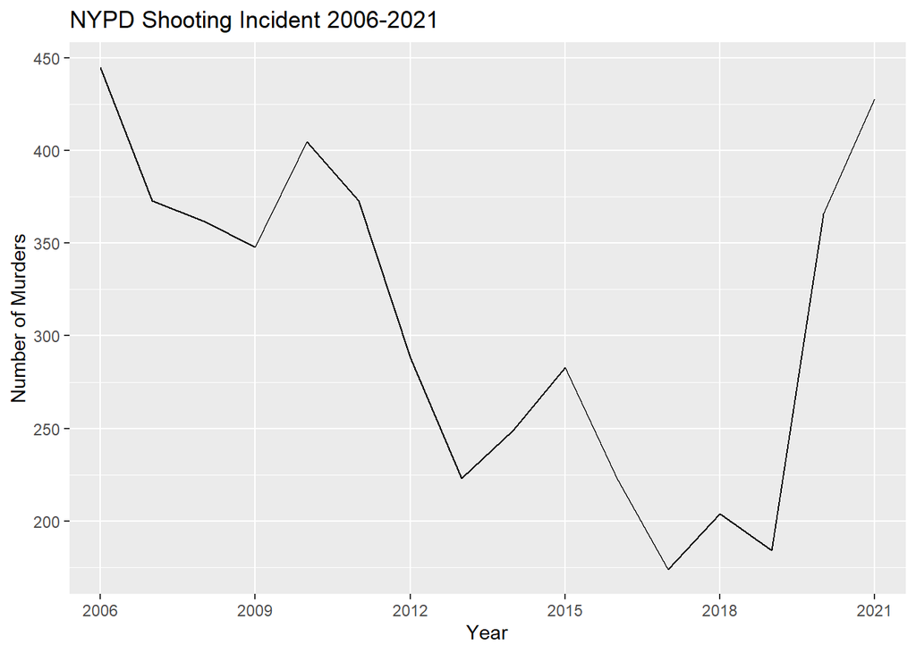

```r
murder_by_year %>%
  filter(STATISTICAL_MURDER_FLAG==1) %>%
  ggplot(mapping=aes(x=OCCUR_YEAR, y=num_murder_year))+
  geom_line()+
  scale_x_discrete(limits=c(2006, 2009, 2012, 2015, 2018, 2021))+
  labs(title="NYPD Shooting Incident 2006-2021", x="Year", y="Number of Murders")
```

In the second plot, the total number of murders trended down from 2011 but drastically increased between 2019 to 2021.

### Model & Prediction

```r
murder_year_model <- lm(num_murder_year~lag(num_murder_year), data=murder_by_year)
summary(murder_year_model)
```

```
##
## Call:
## lm(formula = num_murder_year ~ lag(num_murder_year), data = murder_by_year)
##
## Residuals:
##     Min      1Q  Median      3Q     Max
## -73.845 -55.247   1.155  16.345 143.996
##
## Coefficients:
##                      Estimate Std. Error t value Pr(>|t|)
## (Intercept)          100.0828    62.1599   1.610  0.13138
## lag(num_murder_year)   0.6626     0.1995   3.322  0.00551 **
## ---
## Signif. codes:  0 '***' 0.001 '**' 0.01 '*' 0.05 '.' 0.1 ' ' 1
##
## Residual standard error: 65.14 on 13 degrees of freedom
##   (1 observation deleted due to missingness)
## Multiple R-squared:  0.4591, Adjusted R-squared:  0.4175
## F-statistic: 11.03 on 1 and 13 DF,  p-value: 0.005511
```

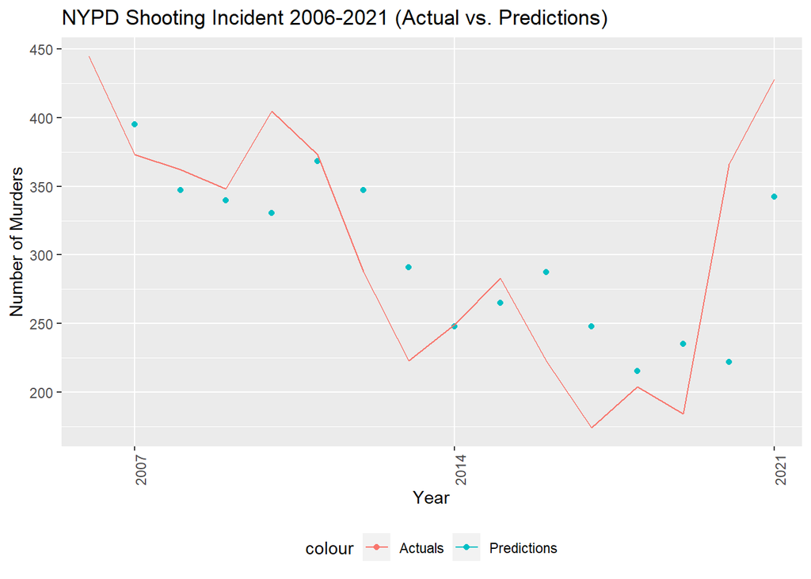

```r
pred <- predict(murder_year_model)
new_df <- as.data.frame(pred)
x_grid <- rep(2007:2021)

ggplot(mapping=aes(x=x_grid, y=new_df$pred))+
  geom_point(aes(x=x_grid, y=new_df$pred, color="Predictions"))+
  geom_line(aes(x=murder_by_year$OCCUR_YEAR, y=murder_by_year$num_murder_year, color="Actuals"))+
  scale_x_discrete(limits=c(2007, 2014, 2021))+
  theme(legend.position="bottom", axis.text.x=element_text(angle=90))+
  labs(title="NYPD Shooting Incident 2006-2021 (Actual vs. Predictions)", x="Year", y="Number of Murders")
```

## Bias, Conclusion & Further Discussion

From the first visualization, we could see that murders are concentrated at late nights and in the early mornings, which are in line with our intuition about the occurrences of murders, away from daylights and possible attention. The time-series linear regression would help look into forecast of number of murders based on the prior year. R-squared is relatively weak in this case at 42%, given that other factors in recent years could have added to the number of murders, such as COVID-19, which could have contributed to the uptick between 2019 to 2021. Several other factors may also affect the number of murders such as COVID-19 infections impacting the police force, anger or other sentiments due to COVID-related lock-downs.

Other bias that need to be considered include the total number of shootings and murders as a percentage of the total number of shootings, these time-series data could have changed over the span of sixteen years or they could have been more stagnant even though the number of murders increased during the COVID-19 period. Additional analysis could be done with the victim age groups and race to determine whether there is a stronger relationship between targeted murders and the COVID-19 time period. Although the linear regression presented is not the best model to predict number of murders, where we can see some of the scattered plots (ie. prediction) above the actual and some below the actual, it follows that there may be some relationship that exists between the current year and prior year numbers.

#### Appendix

The following packages are needed if they are not installed. This is a reference and appendix to the original R markdown and code.

stringr

tidyverse